# Regression_write_up

Jennifer Philippou

December 18, 2017

[output not shown]

[output cut: 27 more lines]

```r
#NEED FOR REGRESSIONS + POWER CALC
#prep data
df_female = subset(df, df$female == 1)
#changes missing values to something easier to delete (done later)
df_female[,"age"][is.na(df_female[,"age"])] = 0.0001
df_female = subset(df_female, df_female$age != 0.0001)
library(sandwich)
library(lmtest)
```

Results: As a research team we were extremely excited to see any kind of results. In the pilot and in the first round of testing we struggled with a low overall match rate (0/400 swipes and 5/1,600 respectively) and therefore we could not perform initial calculations to evaluate the treatments’ effect. The primary concern was that the Tinder user made decisions based solely on physical attractiveness and there would be no variance across our treatment variable. It wasn’t until week four of swiping that we could compare the numbers across treatments. Unfortunately the data points from the pilot and the second week of the project would have introduced too much bias because the profiles were modified thereafter; so the data was excluded from the analysis.

High Level Overview of Outcomes

```
##        Female Indicator
## Matches    0    1  Sum
##     0   3161 2524 5685
##     1     13  571  584
##     Sum 3174 3095 6269
```

```
##        Treatment
## Matches   BS   MD NoEdu  PhD  Sum
##     0   1468 1330  1454 1433 5685
##     1    127  177   135  145  584
##     Sum 1595 1507  1589 1578 6269
```

Before building sophisticated models, the research team paused to consider the power of the experiment. While the delta between the treatment and control means was very small, the large sample size engenders a high powered experiment.

Actual Power of the experiment:

```r
#Parameters
alpha = 0.05
mu_c = mean(df_female$matches[df_female$noedu==1])
mu_c
```

```
## [1] 0.160414
```

```r
mu_t = mean((df_female$matches[df_female$md==1]),na.rm = T)
mu_t
```

```
## [1] 0.2289326
```

```r
sigma = sd((df_female$matches[df_female$md==1]),na.rm = T)

#calc final - individual level
n_1 = 3034
power_indiv = pnorm(((abs(mu_t-mu_c))*sqrt(n_1))/(2*sigma)-qnorm(1-(alpha/2)))
power_indiv
```

```
## [1] 0.9942697
```

Modeling Choices: To better understand the predictive power and magnitude of each variable the research team exclusively leveraged regression models. This type of model is known for being highly interpretable and there are many different varieties of regression available. For analyzing our experiment we selected both linear and logistic model implementations.

Part I Linear Regression:

The first model shown below is a standard ordinary least squares regression where the outcome variable is the linear measurement of the match variable. As the regression table shows, we regressed the match indicator against each of the treatments, the female indicator and we also tested for interactions between the treatment variables and gender. The highest level of education, MD, has a positive and significant ATE of 0.06 for the female account meaning that the number of matches actually increased by 6% when the treatment was applied compared to when the control group with no education information was applied. Prior observational research from match.com indicated that income levels for females was not significant and it is surprising to see a different pattern. The regressions shows there were no other statistically significant variables so the other treatment variables, BS and PhD, did not provide evidence of causal relationships.

## Models

$$y_i = {\beta}_0 + {\beta}_1Z_i + e_i \\
Y_{Matches} = \beta_0 + \beta_1 MD + \beta_2 PhD + \beta_3 BS + \beta_4 female + \beta_5 female* MD + \beta_6 female*PhD + \beta_7 female*BS + e_i \\$$

```
##
## Call:
## lm(formula = matches ~ md + bs + phd + female + female * md +
##     female * bs + female * phd, data = df)
##
## Residuals:
##      Min       1Q   Median       3Q      Max
## -0.23659 -0.16857 -0.00641 -0.00250  0.99874
##
## Coefficients:
##              Estimate Std. Error t value Pr(>|t|)
## (Intercept)  0.002500   0.009745   0.257  0.79754
## md           0.003910   0.013870   0.282  0.77801
## bs           0.003734   0.013773   0.271  0.78629
## phd         -0.001237   0.013816  -0.090  0.92864
## female       0.166068   0.013830  12.008  < 2e-16 ***
## md:female    0.064111   0.019828   3.233  0.00123 **
## bs:female   -0.018456   0.019539  -0.945  0.34492
## phd:female   0.015876   0.019592   0.810  0.41779
## ---
## Signif. codes:  0 '***' 0.001 '**' 0.01 '*' 0.05 '.' 0.1 ' ' 1
##
## Residual standard error: 0.2756 on 6261 degrees of freedom
##   (1 observation deleted due to missingness)
## Multiple R-squared:  0.1018, Adjusted R-squared:  0.1008
## F-statistic: 101.4 on 7 and 6261 DF,  p-value: < 2.2e-16
```

The research team did have some concerns regarding the validity of a linear regression with a binary outcome variable. With any regression model it is important to consider the BLUE assumptions, which is exactly what the plots below explore:

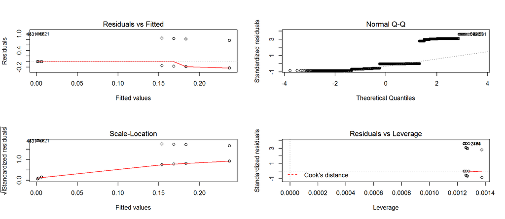

To address the violated homoskedacity seen the in residuals vs fitted and scale-location graphs above, gender model 2 uses robust standard errors, but the coefficient estimates are still the same. More importantly, the female MD treatment is still statistically significant even with a wider confidence interval generated with the robust standard errors.

```r
library(sandwich)
model_gender2 = coeftest(model_gender, vcov = vcovHC)
model_gender2
```

```
##
## t test of coefficients:
##
##               Estimate Std. Error t value  Pr(>|t|)
## (Intercept)  0.0025000  0.0017678  1.4142  0.157349
## md           0.0039103  0.0033633  1.1626  0.245021
## bs           0.0037344  0.0032969  1.1327  0.257379
## phd         -0.0012374  0.0021728 -0.5695  0.569056
## female       0.1660678  0.0134614 12.3366 < 2.2e-16 ***
## md:female    0.0641107  0.0209408  3.0615  0.002212 **
## bs:female   -0.0184561  0.0188023 -0.9816  0.326342
## phd:female   0.0158757  0.0193307  0.8213  0.411525
## ---
## Signif. codes:  0 '***' 0.001 '**' 0.01 '*' 0.05 '.' 0.1 ' ' 1
```

```r
library(stargazer)
#location model
model_location = lm(matches ~ md + bs + phd  + losangeles + houston + newyork + phoenix + sandiego +sanantonio +philadelphia, data = df_female)
model_location2 = coeftest(model_location, vcov = vcovHC)
#age
model_age = lm(matches ~ md + bs + phd  + age  , data = df_female)
model_age2 = coeftest(model_age, vcov = vcovHC)
#details
model_details = lm(matches ~ md + bs + phd  +  school + job, data = df_female)
model_details2 = coeftest(model_details, vcov = vcovHC)

#all
model_all = lm(matches ~ md + bs + phd  +  age + losangeles + houston + newyork + phoenix + sandiego +sanantonio +philadelphia +  school + job  , data = df_female)
model_all2 = coeftest(model_all, vcov = vcovHC)
#Change type to "latex" for knitting to pdf or text for R viewing
stargazer(model_gender2, model_age2, model_location2, model_details2, model_all2,type = "latex", report = "vcs*", single.row = T, column.labels = c("Base","Age", "Location", "Details", "All"), title ="Comparison of treatments")
```

[output not shown]

```r
#cat("\n\n\\pagebreak\n")
```

Part II Logistic Regression: After reviewing the results of five different regression models the research team observed that all of the coefficients very low and we could not shake the feeling that something was off. After some research we found that models with probabilities close to 0 and 1 are prime candidates for logistic regression. What does it mean for a probability to be close to 1? If you take the results from the baseline model and plug in a test case, for this example consider a male with an MD, the probability of receiving a match is 0.0064 (calculation built off of baseline regression) or practically 0.
$$\begin{aligned}
p =& 0.0025 + 0.0039 *1 \\
p =& 0.0064
\end{aligned}$$

We updated our modeling technique to logistic regression to better fit the data. The regression output below shows a consistently statistically significant female indicator, but instead of the model coefficients showing percentage point difference in probability, the logistic model outputs a log odds ratio. This is a very difficult to interpret measure so we exponentiated the coefficients and interpreted them as regular odds-ratios. The coefficient 4.39 for the female indicator actually means the probability of having a match based on that variable alone (see table converting odds ratios to probability for support) is over 90% and this magnitude of influence is much more practically significant than the 16% seen in the Linear model. The other important call out is that the treatment variable interacted with the female indicator is no longer statistically significant. While the regression coefficient now looks negative, it must be converted to an odds ratio. After that transformation, the probability of a match for a female with an MD is actually a positive 35% probability. Based on our original raw numbers we know that the observed MD match rate is closer to 20% and our new model also has a very large weight on the intercept, indicating there is more analysis needed.

```
##
## Call:
## glm(formula = matches ~ md + bs + phd + female + female * md +
##     female * bs + female * phd, family = "binomial", data = df)
##
## Deviance Residuals:
##     Min       1Q   Median       3Q      Max
## -0.7348  -0.6076  -0.1134  -0.0708   3.6536
##
## Coefficients:
##             Estimate Std. Error z value Pr(>|z|)
## (Intercept)  -5.9890     0.7080  -8.459  < 2e-16 ***
## md            0.9455     0.8382   1.128    0.259
## bs            0.9175     0.8382   1.095    0.274
## phd          -0.6843     1.2258  -0.558    0.577
## female        4.3931     0.7144   6.150 7.76e-10 ***
## md:female    -0.5212     0.8481  -0.615    0.539
## bs:female    -1.0265     0.8493  -1.209    0.227
## phd:female    0.7854     1.2329   0.637    0.524
## ---
## Signif. codes:  0 '***' 0.001 '**' 0.01 '*' 0.05 '.' 0.1 ' ' 1
##
## (Dispersion parameter for binomial family taken to be 1)
##
##     Null deviance: 3884.0  on 6268  degrees of freedom
## Residual deviance: 3105.3  on 6261  degrees of freedom
##   (1 observation deleted due to missingness)
## AIC: 3121.3
##
## Number of Fisher Scoring iterations: 9
```

```
##  (Intercept)           md           bs          phd       female
##  0.002506266  2.574193548  2.503136763  0.504424779 80.894817073
##    md:female    bs:female   phd:female
##  0.593808575  0.358265452  2.193225315
```

```r
library(stargazer)
#prep data
df_female = subset(df, df$female == 1)
#changes missing values to something easier to delete (done later)
df_female[,"age"][is.na(df_female[,"age"])] = 0.0001
df_female = subset(df_female, df_female$age != 0.0001)

#location model
Lmodel_location = glm(matches ~ md + bs + phd  + losangeles + houston + newyork + phoenix + sandiego +sanantonio +philadelphia,  data = df_female, family = "binomial")
#age
Lmodel_age = glm(matches ~ md + bs + phd  + age  , data = df_female, family = "binomial")
#details
Lmodel_details = glm(matches ~ md + bs + phd  +  school + job, data = df_female, family = "binomial")

#all
Lmodel_all = glm(matches ~ md + bs + phd  +  age + losangeles + houston + newyork + phoenix + sandiego +sanantonio +philadelphia +  school + job  , data = df_female, family = "binomial")
#Change type to "latex" for knitting to pdf
stargazer(Lmodel_gender, Lmodel_age, Lmodel_location, Lmodel_details, Lmodel_all,type = "text", report = "vcs*", single.row = T, column.labels = c("Base","Age", "Location", "Details", "All"), title ="Comparison of treatments")
```

# Comparison of treatments

```
                                                Dependent variable:
              ----------------------------------------------------------------------------------------
                                                      matches
                    Base              Age            Location           Details             All
                     (1)              (2)               (3)               (4)               (5)
```

| md 0.946 (0.838) 0.444 (0.133)*** 0.426 (0.135)*** 0.439 (0.133)*** 0.429 (0.136)*** |
| --- |
| bs 0.918 (0.838) -0.081 (0.141) -0.099 (0.143) -0.097 (0.141) -0.091 (0.144) |
| phd -0.684 (1.226) 0.179 (0.135) 0.171 (0.137) 0.167 (0.135) 0.183 (0.137) |
| female 4.393 (0.714)*** |
| md:female -0.521 (0.848) |
| bs:female -1.026 (0.849) |
| phd:female 0.785 (1.233) |
| age -0.036 (0.018)** -0.048 (0.018)*** |
| losangeles 0.876 (0.169)*** 0.891 (0.171)*** |
| houston -0.522 (0.203)** -0.527 (0.204)*** |
| newyork -0.081 (0.187) -0.063 (0.188) |
| phoenix -0.421 (0.198)** -0.432 (0.199)** |
| sandiego -0.007 (0.185) -0.014 (0.186) |
| sanantonio -0.390 (0.210)* -0.399 (0.211)* |
| philadelphia -0.347 (0.196)* -0.360 (0.196)* |
| school -0.058 (0.096) -0.022 (0.099) |
| job 0.039 (0.116) 0.049 (0.118) |
| Constant -5.989 (0.708)*** -0.652 (0.500) -1.595 (0.158)*** -1.631 (0.113)*** -0.271 (0.531) |

Observations 6,269 3,034 3,034 3,034 3,034  
Log Likelihood -1,552.673 -1,417.188 -1,373.097 -1,419.059 -1,369.560  
Akaike Inf. Crit. 3,121.345 2,844.376 2,768.194 2,850.119 2,767.119  
========================================================================================================== Note: *p<0.1; **p<0.05;*** p<0.01

```r
#cat("\n\n\\pagebreak\n")
```

[output not shown]